# When biomarkers, assays, and protocols co-evolve

Cross-platform reproducibility, validation, and adaptive design — FDA CDRH OSEL Seminar

Naim Rashid, PhD  
Associate Professor, Department of BiostatisticsUNC Gillings School of Global Public HealthMember, UNC Lineberger Comprehensive Cancer Centernaim@unc.edu · naimurashid.github.io

2026-05-20

# §1 — ADAPT: the case study

## Metastatic cancer: why progress stays incremental

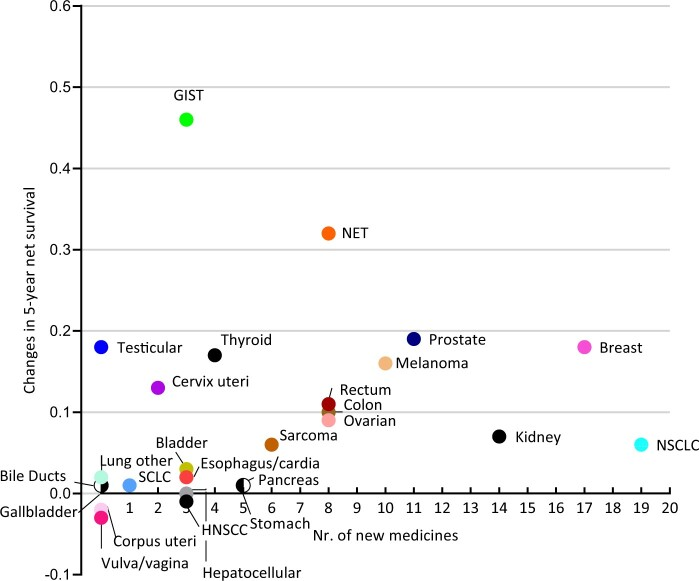

*JNCI 2023*

Despite precision-oncology advances, **metastatic cancer remains a leading cause of death — population-level survival gains stay modest.**

**Why aren’t we seeing bigger gains? Part of the answer is structural — and it is what ADAPT targets:**

- Trials are **fixed**, not adaptive — they cannot re-route as resistance emerges
- Biomarkers are read **once at baseline**, not followed continuously
- Discovery is **retrospective** — findings arrive after the trial closes

## The ARPA-H ADAPT opportunity

[figure not shown]

*March 2024: ARPA-H launches ADAPT to close those three gaps.*

**The ARPA-H ask:** Design an adaptive multi-line trial to **discover, evaluate, and implement** never-before-seen baseline and longitudinal biomarkers **in real time** — including **N-of-1 arms** (single-patient adaptive arms) — on a **one-month submission timeline**.

*Three verbs — discover, evaluate, implement — that this talk will return to as a single arc.*

## Longitudinal and multi-modal biomarkers

[figure not shown]

*Longitudinal: measurement before, during, after treatment; arms re-route as resistance emerges.*

[figure not shown]

*Multi-modal: single-gene → multi-platform predictive biomarkers.*

**The regulatory problem:** biomarker discovery, assay transfer, validation, and protocol decision rules usually live in **separate pipelines**. ADAPT forces them into one system — and that coupling is the subject of this talk.

## ADAPT’s structure — three Technical Areas, one of them EVOLVE

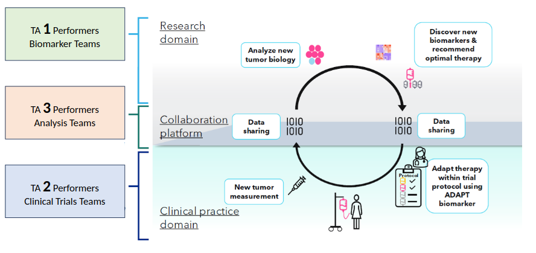

*TA1 (biomarker engine) ↔︎ TA2 (the trials) ↔︎ TA3 (data infrastructure). TA2 sends samples to TA1; TA1 proposes candidate biomarkers back as new targeting arms. The TA numbers label the areas — they are not the flow order.*

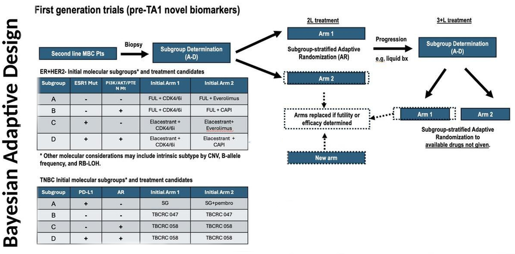

**EVOLVE-BDT** (NCT07340541): a biomarker-stratified **multi-arm trial** in 2L metastatic breast cancer — ~700 patients, 10–15 arms; TA1 adds arms as resistance targets emerge. *Structural point: the arm flow; drugs and subgroups are illustrative.*

# §2 — The coupled system

## The same specimen, a different call

A locked biomarker rule classifies a patient’s tumor sample. Call: **biomarker-positive.**

That output determines:

- subtrial / monitoring path
- interim monitoring statistic
- efficacy / futility boundary crossing

**Re-tested on the deployment platform, the same specimen gets a different call.**

**Thesis**

When a biomarker call drives an adaptive trial’s decisions — patient routing, interim stopping — its uncertainty is no longer an assay property; it becomes **part of the trial design**, to be calibrated and evaluated with it.

*Review-relevant object = the coupled system, not the biomarker in isolation.*

## The coupled review object

| Layer | Uncertainty | Control |
| --- | --- | --- |
| Biomarker rule | threshold drift | lock + held-out eval |
| Assay / platform | cross-platform shift | bridging study |
| Population | prevalence shift | scenario envelope |
| Monitoring | weak endpoint link | surrogacy evidence |
| Adaptation | false promotion | simulated OCs |
| Governance | post-hoc changes | pre-specification |

**Each layer carries an uncertainty. All propagate to operating characteristics.**

*The design must hold across the plausible range of these uncertainties — their **envelope** — not a single point estimate.*

*These six aspects bundle concerns that CDRH’s PCCP final guidance (December 2024) addresses separately. In ADAPT, they cannot be reviewed in isolation.*

## One arc: discovery → evaluation → calibration

**The six uncertainty layers are not six separate problems.** Each lives inside one of **three movements** — and each movement is also a device-evaluation question. This is the arc for the rest of the talk.

| Arc movement | The question it answers | This talk | Device-review counterpart |
| --- | --- | --- | --- |
| **Discovery** (§3) | Does a biomarker survive the move to the trial’s measurement platform? | Cross-platform reproducibility; rank-based transfer (RIF) | Cross-deployment classifier drift |
| **Evaluation** (§4) | What is the uncertainty in each call, and how does it propagate to trial decisions? | Per-patient conformal uncertainty; PPoS; classification-error propagation | Per-prediction uncertainty for AI/ML classifiers |
| **Calibration** (§5) | Can we find a design whose operating characteristics hold across that uncertainty? | Simulation-based constrained calibration (BATON) | Premarket simulation for adaptive device trials |

*Discover, evaluate, implement — the ARPA-H verbs — read in two vocabularies at once.*

# §3 — Discovery: biomarkers across platforms

## Three kinds of biomarker decision rule

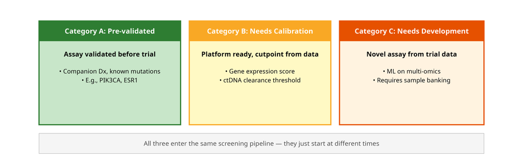

**Three kinds of biomarker enter ADAPT as decision rules** — each mapping onto one of the figure’s readiness tiers:

- a **measured marker** with an established cutpoint — *pre-validated*
- a **prediction-model score** (PurIST, RIF, Oncotype) — *needs calibration*
- a **multimodal composite** fused across platforms — *needs development*

The tier sets how much calibration each kind needs — but each, once it drives a decision, carries uncertainty into the trial design.

*Our worked example below uses **PurIST**, a pancreatic-cancer subtype classifier — chosen because it has mature cross-platform validation data. The machinery is identical for EVOLVE’s breast-cancer biomarkers.*

## Cross-platform reproducibility: training versus deployment

**The platform-transfer problem is distribution shift** — a measurement/representation shift between the training and deployment platforms (the feature scale itself changes), not random noise. *Locking the rule is the precondition for evaluation; PCCP then defines what controlled change is permitted after the locked snapshot.*

**Real ADAPT example.** A classifier developed on RNA-seq, applied directly to Tempus XR:

- Predicted values may be **out of range / uninterpretable**
- Locked clinical thresholds are **non-transferable**
- Classifier *and* cutpoints must be re-bridged before trial use

**Bridging-study metrics:** percent agreement and Cohen’s κ — the analytical-reproducibility layer.

**Imaging / ML analogs:** cross-scanner harmonization, cross-vendor MRI, model drift.

**OSEL connection.** Cross-platform bridging is the same review object as **cross-deployment reproducibility for AI/ML devices** under PCCP. In-trial validation does not substitute for it.

## RIF: a rank-based answer to distribution shift

**Rank Invariant Forest (RIF)** — our lab’s rank-based classifier — classifies by **gene-pair rank order**, invariant to the monotone platform shifts that break absolute-expression models.

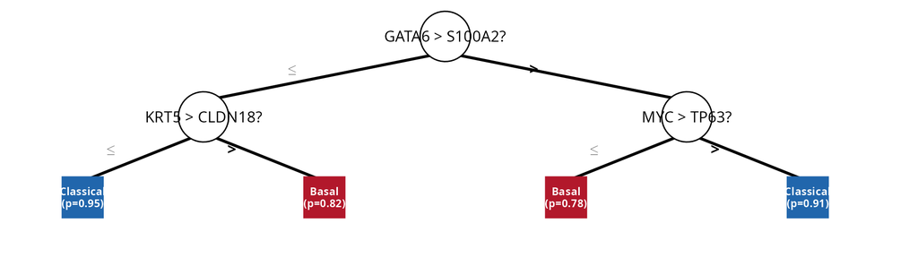

*Each split is a gene-pair **rank comparison** (e.g., GATA6 > S100A2?). Ranks survive monotone platform shifts; absolute expression levels do not.*

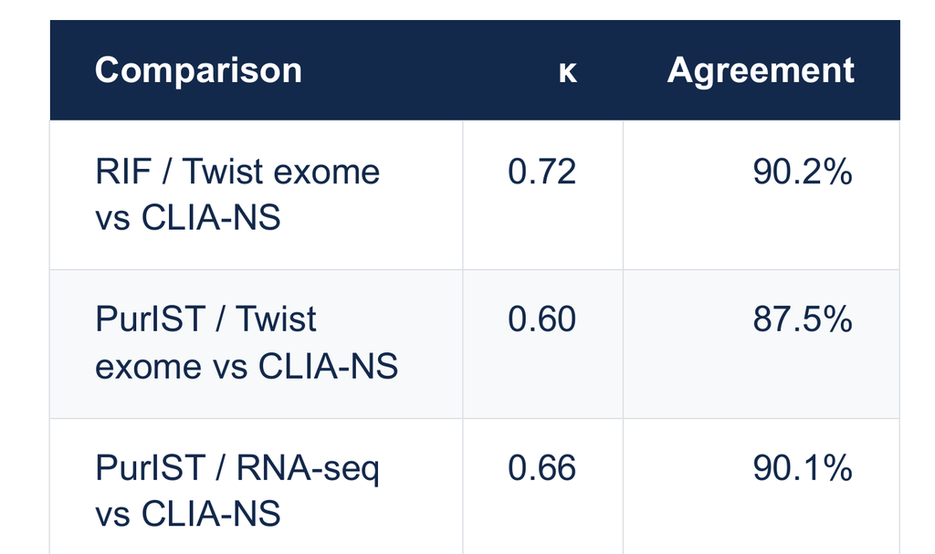

**Worked example (non-ADAPT, pancreatic).** Vs the CLIA-NS reference: PurIST holds up on its native RNA-seq (κ = 0.66) but degrades on Twist exome (κ = 0.60). On Twist exome, **RIF reaches κ = 0.72** — closing the gap.

*Rank-based transfer handles distribution shift — not the **per-patient** uncertainty that §4 takes up.*

# §4 — Evaluation: per-patient uncertainty

## The uncertainty-quantification (UQ) gap for model-derived biomarkers

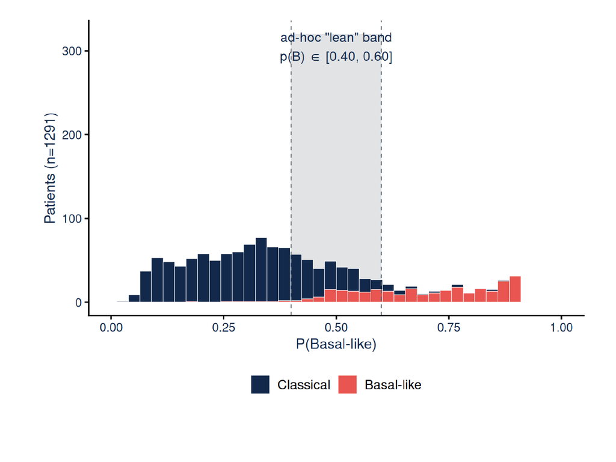

**A device may output a calibrated score — but the decision protocol that consumes it collapses to a hard call.** The gap is between the score and the action.

- Most classifiers output a **point probability** — the decision is made on the dichotomized call (PurIST, for example, splits Basal-like from Classical at a **0.5** cutoff)
- “Lean” / “borderline” zones are **ad hoc cutoffs**

**The harm:** at decision time, a borderline call and a confident call look **identical**. The clinician acts on a hard label with no quantified confidence.

**For OSEL:** AI/ML devices with a PCCP that lock thresholds without a per-prediction UQ layer give reviewers no visibility into which calls were borderline.

## RIF response: a data-driven Mixed / no-call zone

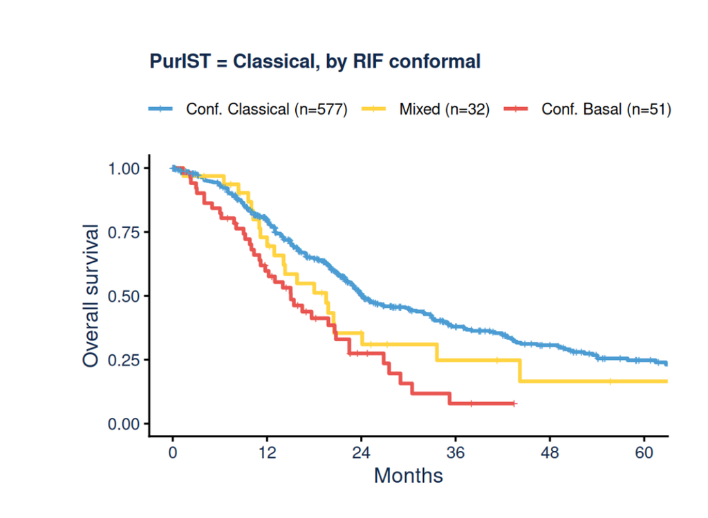

*Within PurIST-Classical (n = 660), split by RIF conformal call.*

- **Conformal prediction** wraps a score into a rule with a **finite-sample coverage guarantee**
- RIF carves a **data-driven Mixed zone** — width **set by the data** to a 92.5% coverage target
- Binary PurIST collapses all of these into “Classical”

| RIF conformal stratum | HR | 95% CI |
| --- | --- | --- |
| **Confident Classical** | ref | — |
| **Mixed** | 1.49 | 0.96–2.33 |
| **Confident Basal** | 2.30 | 1.62–3.25 |

Mixed survival sits **between** the confident classes — intermediate, not noise.

## RIF adds two strata — each changes a different decision

Conformal RIF splits the binary “Classical” call into **three strata** — the **two new ones drive two distinct actions**.

**Correction 1 — reclassification**

PurIST calls all 660 patients “Classical”; RIF’s conformal call splits them:

| PurIST call | Conf. Classical | Mixed | Conf. Basal |
| --- | --- | --- | --- |
| Classical (n = 660) | 577 (87%) | 32 (5%) | **51 (8%)** |

The **8% reclassified Confident Basal** — **HR 2.30**, 9-month OS gap — are **wrong by default** under binary PurIST.

**Correction 2 — abstention (Mixed)**

RIF flags an **intermediate stratum**, confidently *neither* class — **HR 1.49** (CI crosses 1).

Action: orthogonal work-up; defer therapy until disambiguated.

*Abstention is a design knob, not a free lever — it needs orthogonal testing available and reimbursed.*

**OSEL principle.** A pre-specified abstention layer is a **risk-control primitive** — coverage-guaranteed uncertainty added without revisiting the locked classifier.

## Evaluating a proposed biomarker: PPoS

Before a biomarker earns a **targeted intervention** (an N-of-1 or expanded arm), the trial must show *prospectively* that B+ and B− differ in survival (progression-free survival, PFS). **PPoS — predictive probability of success — is, at each interim, the probability the final analysis would declare a B+/B− difference if the trial ran to its planned end** (from the current posterior).

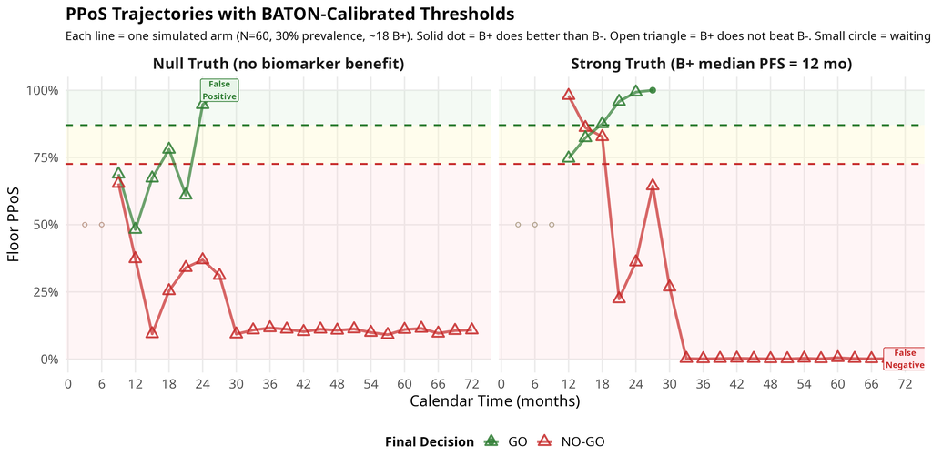

**Detection** — a GO when B+/B− truly differ; **false promotion** — a GO when they don’t. *(Figure: “False Positive” = false promotion; “False Negative” = missed biomarker; thresholds set by BATON, §5.)* *Next: how classification error moves both.*

## Biomarker uncertainty propagates to screening power

**The biomarker call itself is not error-free.** Aggregated over an arm, classification error degrades the detection and false-promotion probabilities just defined.

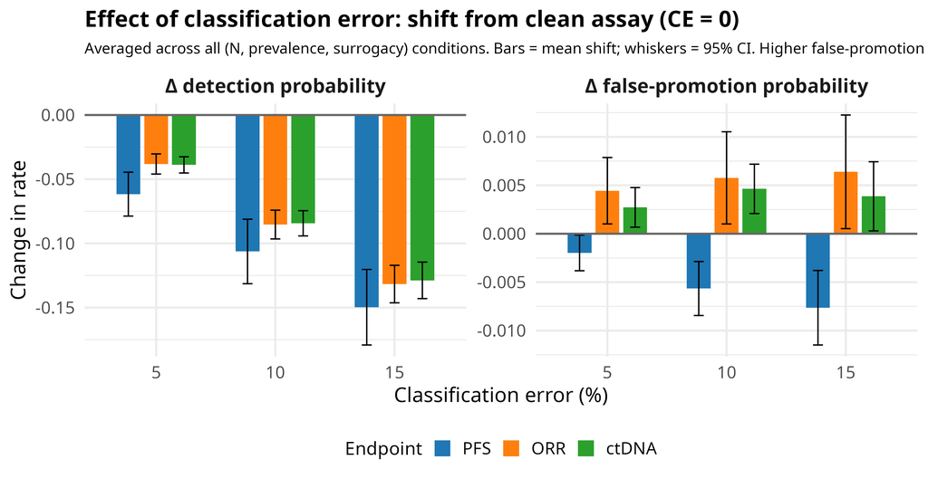

**Nondifferential classification error** (figure: three endpoints — PFS, ORR, ctDNA): **false-promotion barely moves** (Δ < 3 pp), but **detection drops sharply** — on ORR, −9 pp at CE = 10%, −13 pp at CE = 15%. Misclassification **attenuates** the true effect and cuts power.

**The §2 envelope, made concrete: CE → detection probability** — a real loss of screening power, not an inflation of false promotion.

## When propagation becomes bias: differential drift

**The dilution argument holds only if classification error is nondifferential.** When error correlates with site, outcome, treatment, or platform, the argument breaks — and bias returns.

**Differential failure modes:**

- Vendor-by-center differences
- Batch effects correlated with outcome timing
- Prevalence shift across sites
- Sample-QC concentrated in one stratum

**The transferable diagnostic — for OSEL:** *Is observed drift nondifferential with respect to subpopulation, outcome, site, or deployment environment?*

- **If yes** → loss of sensitivity dominates
- **If no** → bias and false-positive control return as central review concerns

This is the **post-market drift question** for AI/ML devices with a PCCP — same diagnostic, different submission type.

# §5 — Calibration: trial design with BATON

## Why calibration needs a guided search

*The open question is now calibration: can we find a design that survives all of it?*

Bayesian adaptive trials with biomarker-driven adaptation have **no closed-form operating characteristics** — each design $\boldsymbol{\theta}$ maps by simulation to $\boldsymbol{\theta} \to (\text{Power}, \text{Type I}, E_0[N], E_1[N], N_{\max})$.

**Goal:** minimize expected enrollment under regulatory constraints — over **6–13 interacting parameters** that cannot be tuned in isolation.

**The manual loop** — choose → simulate → check → adjust → repeat — does not scale: random search is **6.8% feasible** (2,000 designs); grid search yields **zero** designs at power ≥ 0.80; manual EVOLVE calibration took **2 weeks and failed** (power 0.78).

Three governance gaps remain: **local search**, **person-dependent** designs, **no audit trail**.

A guided, simulation-based search is needed — one that is **reproducible and auditable**, not just fast.

## Simulation-based calibration: the operating standard

**Regulatory posture.** For Bayesian / adaptive designs with no closed-form operating characteristics, FDA-facing justification of thresholds and stopping rules is established through **clinical trial simulation** — per FDA’s Bayesian and adaptive-design guidance.

**Stays human:** endpoint choice, prior specification, benefit-risk judgment.

**The framework extends.** Because calibration is simulation-based, biomarker uncertainty *can* enter the loop directly — uncertain routing and outcome association are simulable like any design element. Bringing them **inside the same search** is the natural extension (§6).

**BATON — our simulation-based design-calibration method — makes the threshold-search reproducible and auditable.** Judgment stays with the committee; the search becomes a documented procedure with a stress-test envelope.

## BATON: smart search through design space

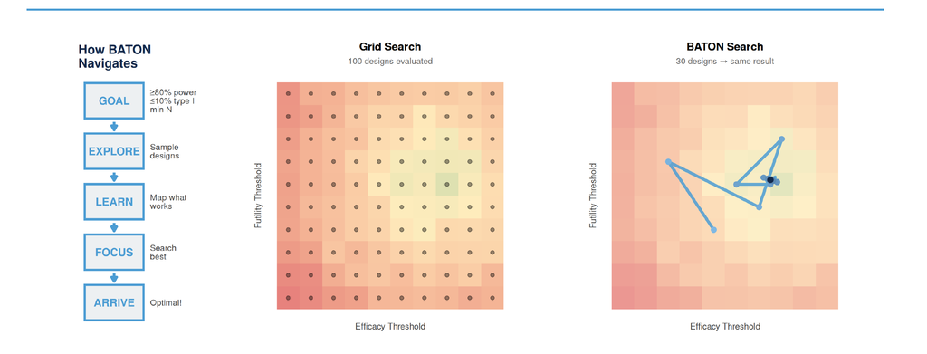

- **BATON** learns a surrogate map of the design space, then samples where feasible designs are likely
- Reaches a comparable optimum in **~150 evaluations** — far fewer than grid or the 2,000-design random search (6.8% feasible)
- The same **Bayesian optimization** used for expensive black-box tuning
- *Same review object as simulation-calibrated change-control rules for AI/ML devices*

*Panels above: a schematic 2-D illustration of the search contrast — not the EVOLVE design counts.*

*In development — **BATON-C** extends the search to calibrate robustly across an envelope of uncertain trial assumptions (accrual, hazards, priors), not a single fixed point.*

## Validation — unit test: matches Simon optimal

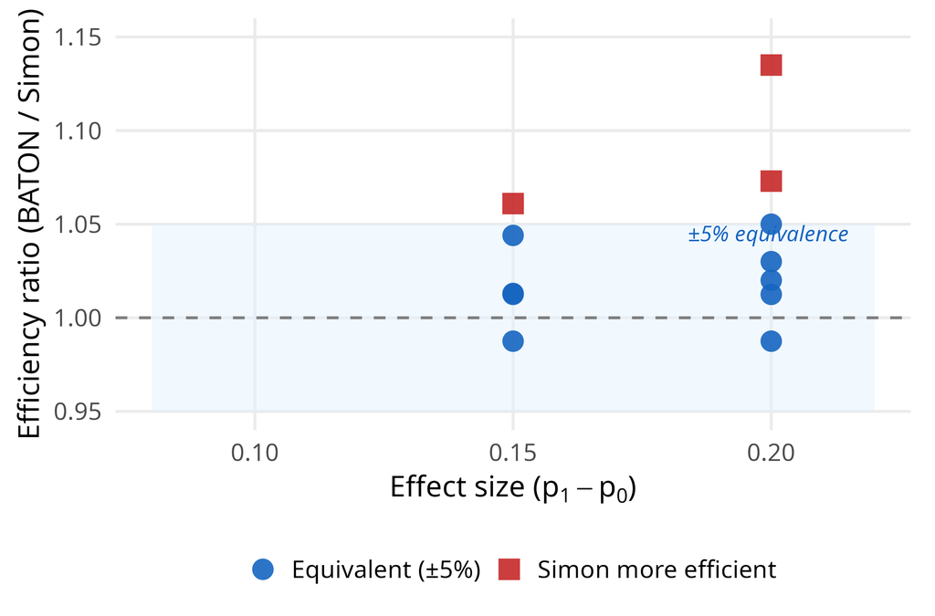

*12 Simon two-stage designs — a standard phase-II benchmark with known optima; no Simon-specific knowledge given to BATON.*

*The integration test — EVOLVE-like calibration with no closed-form ground truth — is §3–§5 of this talk.*

## Validation — reproducibility across independent runs

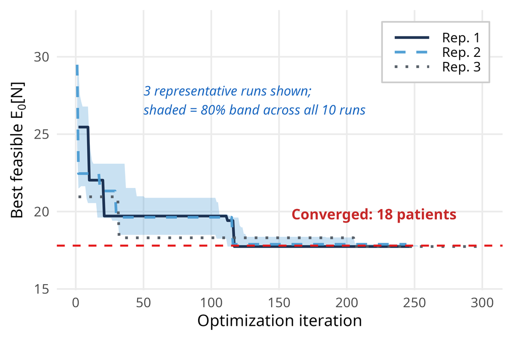

*10 independent runs of the same calibration problem.*

- Coefficient of variation of $E_0[N]$ **< 1%** across runs
- Convergence in ~150 iterations
- **BOBYQA** (a standard derivative-free optimizer): 30 runs → **zero** feasible

## Calibration exposes trade-offs before launch

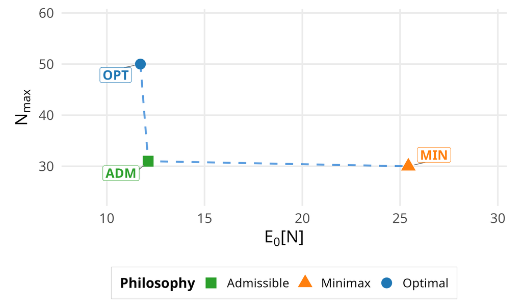

*An illustrative single-arm scenario: three of the five philosophies located in $(N_{\max}, E_0[N])$ space.*

**Same constraints, different objectives:**

| Philosophy | Objective |
| --- | --- |
| Optimal | min $E_0[N]$ |
| Minimax | min $N_{\max}$ |
| Fleming | min avg $E[N]$ |
| Alt-Optimal | min $E_1[N]$ |
| Admissible | Pareto frontier |

**The point isn’t a “best” design — it’s an auditable trade-off space the steering committee can interrogate before launch.**

## Operational impact — a defensible calibration record

**EVOLVE calibration comparison:**

|  | Manual | BATON |
| --- | --- | --- |
| **Audit trail** | **Incomplete** | **Full** |
| **Stress-test envelope** | **Ad-hoc** | **Pre-specified** |
| **Reproducibility** | **Person-dependent** | **Reproducible (fixed code + seeds)** |
| Time | 2 weeks | 4 hours |
| Power achieved | 0.78 | 0.83 |

*The audit trail is the propagation record that closes back to the §2 envelope.*

**Downstream use:**

- Pareto frontier informs steering-committee decisions
- Audit trail supports FDA documentation
- Interim timing structures the Data Safety Monitoring Board (DSMB) schedule

# §6 — Translation to OSEL

## The synthesis: one arc, two vocabularies

**The talk traced one arc — discovery → evaluation → calibration — the same three ARPA-H verbs.** Read in two vocabularies, it is the same arc for clinical trials and for device review.

| Arc movement | This talk’s framing | The device-review counterpart |
| --- | --- | --- |
| Discovery | Cross-platform reproducibility under distribution shift | Cross-deployment classifier drift |
| Evaluation | Per-patient uncertainty (conformal) + how it propagates | Per-prediction uncertainty for AI/ML classifiers |
| Calibration | BATON: simulation-based design calibration | Premarket simulation for adaptive device trials |

**EVOLVE** (NCT07340541, ARPA-H ADAPT) is the live deployment.

## Open questions and collaboration invitation

Open directions, each live for OSEL’s AI program:

1. **Robustness by construction.** RIF survives platform shift via rank features. Can that carry to imaging and multi-modal devices — and how is robustness *evaluated*, not just detected post-market?
2. **Simulation-based calibration as a regulatory tool.** BATON calibrates operating characteristics by black-box simulation. What credibility standard lets a reviewer rely on it for device change-control plans?
3. **Conformal guarantees under deployment shift.** Per-prediction coverage assumes exchangeability — which shift breaks. What should conformal guidance for AI/ML classifiers look like?
4. **Joint biomarker-and-design calibration.** The abstention level $\alpha$ is admissible to the same BATON search as the trial parameters. What would an end-to-end joint calibration — and the evidence a reviewer needs to rely on it — require?

**Open to discussing or collaborating on any of these.**

## Acknowledgments + Questions

**Rashid Lab (UNC)**

- Amber Young — *PhD student; led BATON design & validation*

**ADAPT Biomarker UQ Working Group**

- Stephen Bates (MIT)
- Ying Yuan (MD Anderson)
- Qian Cao (FDA CDRH)

**EVOLVE Statistical Working Group**

- Susan Hilsenbeck (Baylor College of Medicine)
- Nabihah Tayoub (DFCI)
- Ruizhe Chen (Johns Hopkins)

**EVOLVE multiple-PI (MPI) team**

- Lisa Carey (UNC)
- Eric Winer (Yale)
- Antonio Wolff (Johns Hopkins)
- Ian Krop (Yale)
- Charles Perou (UNC)

**Funding** — ARPA-H 140D042590009 · DOD HT9425241103100121 · NCI P50-CA058223 · NCI P50-CA257911 · NCI U01-CA274298

**Contact** — naim@unc.edu · naimurashid.github.io · [X](https://twitter.com/naimurashid) · [Bluesky](https://bsky.app/profile/naimurashid.bsky.social) · [GitHub](https://github.com/naimurashid) · [Google Scholar](https://scholar.google.com/citations?user=3Cz_lcEAAAAJ) · [LinkedIn](https://www.linkedin.com/in/naim-rashid-a767aba)

# Backup slides

## B1 · Mechanism — why nondifferential CE is asymmetric (dilution without bias)

Misclassification is approximately **symmetric** across B+/B−.

- **Under null:** swap is invisible → **false-promotion probability unchanged.**
- **Under alternative:** swapping **dilutes** the effect without biasing the test statistic → **power down, Type I unchanged.**

Berkson-style assignment-error (Pepe 2001).

**Quantitatively:**

## B2 · Clinical payoff — what binary calls miss

Within PurIST = Classical patients, RIF-flagged Basal-like calls — the **OS-evaluable cross-cohort replication** of the §4 reclassification result — show:

- **HR 2.21** (95% CI 1.58–3.11, p = 4 × 10⁻⁶) — *OS-evaluable subset, 54 of 660 across 12 cohorts*
- Median OS gap **9 months** (15 vs 24)
- ~8% of OS-evaluable patients (54 of 660)
- **Mixed group:** HR ≈ 1.49 — clinically intermediate survival, between the two confident strata

*Note the two HR figures are different objects, not a discrepancy: **HR 2.30** (CI 1.62–3.25) on the §4 “RIF response” slide is the Confident Basal stratum of the single n = 660 cohort (n = 51 on that slide’s survival curve); **HR 2.21** here is the OS-evaluable subset replicated across 12 cohorts (54 patients). Both are correct; cite whichever matches the question.*

*Available if the conformal-abstention slide draws questions about clinical impact.*

## B3 · Platform-agnostic translation — broader cross-domain table

The framework is platform-agnostic. Same problems, same machinery, different domains.

| Genomics example (this talk) | Imaging / ML analog (this audience) |
| --- | --- |
| PurIST cross-platform CE | Cross-scanner ML classifier drift |
| Tempus vs Guardant vs FoundationOne | Siemens vs GE vs Philips |
| Cross-assay ctDNA harmonization | Cross-vendor MRI harmonization |
| Split-sample bridging study | Phantom / standards-based calibration |
| Conformal Mixed / no-call abstention | Continual-learning device monitoring under PCCP |
| Locked vs recalibratable classifier | Locked vs PCCP-modified algorithm |

## B4 · Random-search baseline for EVOLVE calibration

For perspective on why BATON is needed:

- **Random search** of 2,000 designs → only **6.8%** feasible
- **Grid search** in 6–13 dims → **zero** designs with power ≥ 0.80
- **Manual calibration** of EVOLVE → 2 weeks, power 0.78 (failed)
- **BATON** → ~150 designs, hours, power 0.83 with audit trail

The feasibility region is narrow and non-convex; brute-force methods fail. *(Random search and the grid covered different candidate sets and resolutions; the shared finding is that the feasible region is easily missed by unguided search.)*

## B5 · FDA Bayesian / adaptive guidance — context for Q&A

FDA guidance on Bayesian and adaptive designs has long treated **clinical-trial simulation** as the established way to characterize operating characteristics — type I error, power, expected sample size, stopping probabilities — when a design has no tractable closed-form properties.

Endpoint choice, prior specification, and benefit-risk judgment remain human decisions: simulation calibrates thresholds, it does not replace that judgment.

## B6 · ARPA-H ADAPT program context

For context on the scale and structure of the program:

- **5 modeling groups** (TA1) — biomarker discovery / development
- **2 platform performers** (TA3) — data infrastructure
- **3 disease platforms** (TA2):
  - Lung
  - Colon
  - Breast (**EVOLVE**)
- ~1-month submission timeline at program launch
- N-of-1 capacity embedded in the trial design